# Dramatic Data Deconstruction: A Tutorial on the Data Science Pipeline in Twitch

### Brought to you by: Omar Amin

## Data Collection

Before we can even begin thinking about data, we need to first choose a topic of interest and find the data. Depending on what you are in search of, there are endless online resources with terabytes of data tables ready for use. The team at AwesomeData has done an amazing job compiling a massive list of external links to datasets on other webpages here: https://github.com/awesomedata/awesome-public-datasets. These are all free and publicly available, with topics ranging from agriculture to video games. The provided github page acts as a hub for sourcing large data sets, and even links to other compilations such as Kraggle. Some other sources of locating interesting datasets are from government websites like: https://www.data.gov/, and https://data.virginia.gov/. The national government, states, and even local governments make data universally accessible for browsing.

### Scraping the Data

If downloading readily available data files and importing them seems too easy of a challenge for you, it's time to get into the background behind websites. Assuming you have a Jupyter notebook ready with a python file, all you need to do is import a few libraries in preparation for scraping the data out of websites:

```
from bs4 import BeautifulSoup
import requests
import pandas as pd
```

The requests library is necessary to pull the html code out from a webpage by sending an HTTP request:

```
web = requests.get('https://website.com/sample_data.html')
```

Because the response for this request will be extremely jumbled and difficult to parse by normal means, the BeautifulSoup library allows us to clean up the response and make it presentable:

```
soup = BeautifulSoup(web.content)
print(soup.prettify())
```

Then, you can find the data table you identified in the previous step easily:

```
data_table = soup.find('table', class_='table table-striped table-responsive-md')
```

The last piece of this puzzle is to utilize the Pandas library to structure our data into a presentable table in code. Pandas uses a structure called the DataFrame, which has numerous constructors and parameters to fine tune the extracted data into a DataFrame. When compared to NumPy, which is more oriented towards mathematically manipulating data through operations, Pandas is much more useful for restructuring, cleaning, and organizing data. The best way to learn more about the essential pandas library is to visit the official documentation here: https://pandas.pydata.org/docs/reference/api/pandas.DataFrame.html.

### Downloading the Data

The method of downloading files directly from an online source is the method that will be followed in this tutorial. The source of the dataset is Kaggle, a Google data science company that hosts large datasets on endless topics. We will be exploring the vibrant world of Twitch, a website for livestreaming primarily gaming and eSports content, with some variety mixed in. The website has been booming in viewership and replacing traditional television entertainment with the onset of the COVID-19 era. The purpose of examining this data is to explore the dynamic relationships between many variables encountered in the streaming world, which are mostly tied to consumption and the audience. Hopefully, we will be able to provide some insight on influencer growth and potential areas to focus on for success. This topic was selected due to the author's personal interests, which is a very good motivator for investigating datasets yourself to learn more about fascinating topics.

We will begin first by importing the necessary pandas library, alongside some other libraries for plotting and analysis. When donwloading a *csv* file directly from Kaggle, loading it into a data frame is as simple as using the pandas _read*csv* function, alongside the file name. Then, we can simply display the top twenty results from the table using the *head* function, and passing in 20 as a parameter. With this, we can see a general depiction of the overall table, with all columns present. We can see that the author(s) of the table have sorted it by the Watch time(Minutes) column, and that there are eleven columns in total. There seem to be some columns with information that is superfluous, and you might also encounter extraneous data when performing your own research. To resolve this, we will clean up the dataset in the next step.

```python
# Import the necessary libraries
import pandas as pd
import matplotlib.pyplot as plt
import seaborn as sns

# Download and read in csv table from https://www.kaggle.com/aayushmishra1512/twitchdata
twitch_table = pd.read_csv("twitchdata-update.csv")
twitch_table.head(20)
```

|  | Channel | Watch time(Minutes) | Stream time(minutes) | Peak viewers | Average viewers | Followers | Followers gained | Views gained | Partnered | Mature | Language |
| --- | --- | --- | --- | --- | --- | --- | --- | --- | --- | --- | --- |
| 0 | xQcOW | 6196161750 | 215250 | 222720 | 27716 | 3246298 | 1734810 | 93036735 | True | False | English |
| 1 | summit1g | 6091677300 | 211845 | 310998 | 25610 | 5310163 | 1370184 | 89705964 | True | False | English |
| 2 | Gaules | 5644590915 | 515280 | 387315 | 10976 | 1767635 | 1023779 | 102611607 | True | True | Portuguese |
| 3 | ESL_CSGO | 3970318140 | 517740 | 300575 | 7714 | 3944850 | 703986 | 106546942 | True | False | English |
| 4 | Tfue | 3671000070 | 123660 | 285644 | 29602 | 8938903 | 2068424 | 78998587 | True | False | English |
| 5 | Asmongold | 3668799075 | 82260 | 263720 | 42414 | 1563438 | 554201 | 61715781 | True | False | English |
| 6 | NICKMERCS | 3360675195 | 136275 | 115633 | 24181 | 4074287 | 1089824 | 46084211 | True | False | English |
| 7 | Fextralife | 3301867485 | 147885 | 68795 | 18985 | 508816 | 425468 | 670137548 | True | False | English |
| 8 | loltyler1 | 2928356940 | 122490 | 89387 | 22381 | 3530767 | 951730 | 51349926 | True | False | English |
| 9 | Anomaly | 2865429915 | 92880 | 125408 | 12377 | 2607076 | 1532689 | 36350662 | True | False | English |
| 10 | TimTheTatman | 2834436990 | 108780 | 142067 | 25664 | 5265659 | 1244341 | 50119786 | True | True | English |
| 11 | LIRIK | 2832930285 | 128490 | 89170 | 21739 | 2666382 | 199077 | 50504526 | True | False | English |
| 12 | Riot Games (riotgames) | 2674646715 | 80820 | 639375 | 20960 | 4487489 | 497678 | 56855694 | True | False | English |
| 13 | Rubius | 2588632635 | 58275 | 240096 | 42948 | 5751354 | 3820532 | 58599449 | True | False | Spanish |
| 14 | auronplay | 2410022550 | 40575 | 170115 | 53986 | 3983847 | 3966525 | 41514854 | True | False | Spanish |
| 15 | MontanaBlack88 | 2408460990 | 67740 | 181600 | 33514 | 2911316 | 1101093 | 37189666 | True | True | German |
| 16 | sodapoppin | 2329440420 | 115305 | 107833 | 19659 | 2786162 | 236169 | 39334821 | True | True | English |
| 17 | 풍월량 (hanryang1125) | 2186662470 | 181230 | 26999 | 12201 | 494445 | 92205 | 34405975 | True | False | Korean |
| 18 | alanzoka | 2055003870 | 103770 | 89153 | 19560 | 3445134 | 1325075 | 46515698 | True | False | Portuguese |
| 19 | CohhCarnage | 2029212570 | 175230 | 43615 | 11343 | 1264808 | 124242 | 38718674 | True | False | English |

### Cleaning the Data

In the traditional sense, cleaning the data would require a bit more effort than it might appear in this tutorial. The Kaggle dataset that has been chosen does not have any missing entries, or entirely redundant information that could be compressed. Generally, you would parse the rows through some form of loop, where each missing entry would be replaced with a *NaN* or something similar to indicate the absence of data. This allows us to standardize all missing entries so they can either be ignored or handled in processes later as a single entity. An example of cleansing could follow as shown:

```
for index, row in data_table.iterrows():
    # Replace missing entries with NaN
    row['col1'] = row['col1'].replace('------', 'NaN')
    row['col2'] = row['col2'].replace('****', 'NaN')
    row['col3'] = row['col3'].replace('--.--', 'NaN')
```

In the specific case of our dataset, I noticed that the two columns indicating whether a streamer was partnered, or if their channel was marked as mature, were insignificant in their impact on the research. For example, we can see here that only 230 channels were marked as mature from the entire dataset of 1,000 entries. Also, only 22 channels were not partnered in the entire dataset. While an analysis could be made for how a mature filter affects viewership and followers gained, it is not in the interest of this tutorial to examine the impact of a feature belonging to 23% of the data.

```python
# Counter variables
mature_channels = 0
non_partnered = 0

# Iterate through the rows
for index, row in twitch_table.iterrows():
    # Examine each row for the required conditions and increment if necessary
    if row['Mature'] == True:
        mature_channels += 1
    if row['Partnered'] == False:
        non_partnered += 1

# Print out the results
print("Number of mature channels: " + str(mature_channels) + "\nNumber of non-partnered channels: " + str(non_partnered))
```

```
Number of mature channels: 230
Number of non-partnered channels: 22
```

## Managing the Data

### Dropping and Sorting

Dropping columns altogether is a simple matter with pandas DataFrames, as we can make use of the *drop* method, and include any columns we want to remove in a list, with the *axis* being 1. Now that the columns are dropped, we are free to sort our data any way we choose to. Sorting is just as easy as dropping, with the _sort*values* method. The syntax requires us to list the columns to sort by in order of priority, and then choose whether or not this will be an asceding sort. Due to the fact that I would like to focus primarily on the impact of streaming time, increased followage, and viewer retention, I can set my priorities accordingly. The only issue with sorting is that the indices of the DataFrame object will be jumbled, which we can reorganize with the _reset*index* method.

```python
twitch_table = twitch_table.drop(['Partnered', 'Mature'], axis = 1)
twitch_table = twitch_table.sort_values(by = ['Stream time(minutes)','Followers gained','Views gained'], ascending = False)
twitch_table = twitch_table.reset_index(drop = True)
twitch_table
```

|  | Channel | Watch time(Minutes) | Stream time(minutes) | Peak viewers | Average viewers | Followers | Followers gained | Views gained | Language |
| --- | --- | --- | --- | --- | --- | --- | --- | --- | --- |
| 0 | RiffTrax | 293583075 | 521445 | 24765 | 562 | 79099 | 17200 | 3313465 | English |
| 1 | RelaxBeats | 123273930 | 521430 | 2830 | 235 | 166162 | 29595 | 1094850 | English |
| 2 | Monstercat | 163589370 | 519675 | 14261 | 313 | 788684 | 22331 | 4084222 | English |
| 3 | RocketBeansTV | 360858030 | 518415 | 5223 | 696 | 416018 | 27024 | 5973152 | German |
| 4 | SaltyTeemo | 247613265 | 517980 | 1803 | 476 | 173196 | 36103 | 2117741 | English |
| ... | ... | ... | ... | ... | ... | ... | ... | ... | ... |
| 995 | dota2ti | 1017577605 | 6315 | 483530 | 147643 | 663297 | 121422 | 16228039 | English |
| 996 | dota2ti_ru | 812538090 | 6195 | 457060 | 126232 | 541644 | 108438 | 12068376 | Russian |
| 997 | DreamHackDota2_RU | 152461155 | 6135 | 98717 | 22356 | 203419 | 30231 | 3637232 | Russian |
| 998 | Call of Duty (callofduty) | 130938960 | 3645 | 170131 | 19897 | 968465 | 50321 | 5423366 | English |
| 999 | KEEMSTAR | 123365895 | 3465 | 74195 | 35333 | 146035 | 46367 | 7139253 | English |

1000 rows × 9 columns

### Filtering the Data by Language

Now that we have identified the main goals of examining the dataset, cleaned it up, and organized it, we can start isolating some subsets. Although 1,000 rows is nowhere near a massive amount of data, we can further refine our DataFrame by creating subsets of rows that are similar to each other. The most glaring subset is that of language, so that is what I will be separating by below. Six of the most popular languages were selected based on the code below. A simple list was made from the set of languages in the DataFrame's *Language* column. This list was used to populate a dictionary with all the languages, and then a loop incremented each language by one when encountered in the column. The last step was to sort the languages and note down the top six, because they are relatively close in number. English channels will be the focus of this tutorial.

```python
# This is how to find out all the languages present in the column, removing repetitions
#list(set(twitch_table.Language))

# Create a dictionary to count how many entries are represented per language
channel_count = {'German': 0,'English': 0,'Thai': 0,'Japanese': 0,'Other': 0,'Swedish': 0,'Polish': 0,'Finnish': 0,'Chinese': 0,'Turkish': 0,'Czech': 0,'Hungarian': 0,'Spanish': 0,'Korean': 0,'Greek': 0,'Portuguese': 0,'Italian': 0,'Russian': 0,'French': 0,'Slovak': 0,'Arabic': 0}

# Iterate through the table and increment values in the dictionary
for index, row in twitch_table.iterrows():
    channel_count[row['Language']] = channel_count[row['Language']] + 1

# Display the channel count per language
dict(sorted(channel_count.items(), key = lambda value: value[1]))
```

```
{'Other': 1,
 'Swedish': 1,
 'Finnish': 1,
 'Greek': 1,
 'Slovak': 1,
 'Hungarian': 2,
 'Arabic': 5,
 'Czech': 6,
 'Japanese': 10,
 'Thai': 11,
 'Polish': 12,
 'Italian': 17,
 'Turkish': 22,
 'Chinese': 30,
 'German': 49,
 'Portuguese': 61,
 'French': 66,
 'Spanish': 68,
 'Russian': 74,
 'Korean': 77,
 'English': 485}
```

### Subset Creation

Once again, with the power of the Pandas DataFrame, we can wrap up this procedure in three lines of code for each language. As the language is now attached to the DataFrame's variable name, we are free to drop the Language column as well, because it serves no purpose.

```python
# Filtering data by language

# English channels
english_table = twitch_table[twitch_table.Language == "English"]
english_table = english_table.drop(['Language'], axis = 1)
english_table = english_table.reset_index(drop = True)

# Korean channels
korean_table = twitch_table[twitch_table.Language == "Korean"]
korean_table = korean_table.drop(['Language'], axis = 1)
korean_table = korean_table.reset_index(drop = True)

# Russian channels
russian_table = twitch_table[twitch_table.Language == "Russian"]
russian_table = russian_table.drop(['Language'], axis = 1)
russian_table = russian_table.reset_index(drop = True)

# Spanish channels
spanish_table = twitch_table[twitch_table.Language == "Spanish"]
spanish_table = spanish_table.drop(['Language'], axis = 1)
spanish_table = spanish_table.reset_index(drop = True)

# French channels
french_table = twitch_table[twitch_table.Language == "French"]
french_table = french_table.drop(['Language'], axis = 1)
french_table = french_table.reset_index(drop = True)

# Portuguese channels
portuguese_table = twitch_table[twitch_table.Language == "Portuguese"]
portuguese_table = portuguese_table.drop(['Language'], axis = 1)
portuguese_table = portuguese_table.reset_index(drop = True)
```

## Representation & Analysis

### Plotting the Data

After we have succesfully determined what data we are interested in from the entire dataset, it is time to visually depict it. There are numerous options for showing off the data in question such as line graphs, bar graphs, violin plots, scatter plots, and many more. I have chosen to show a scatterplot to demonstrate some trends in the data, and clusters that may appear where the values are primarily concentrated. Also, while outliers are usually ignored or unhelpful, I am also aiming to examine these special cases and explain their peculiar situations. Before we plot, however, we need to know *why* we are plotting specific variables. Is there something in particular we are looking to prove, or have a predefined belief on? If that is the case, it's time to form a hypothesis! An early hypothesis I have from seeing this data is that simply streaming more does not equate to an increase in followers. The null-hypothesis is the opposite of this assumption, and what we are looking to disprove.

With a hypothesis in mind, all that's left to do is plot our two variables and analyze them. Plotting is done using the matplotlib library, which makes it easy for us to simply plug in our variables and view them without any extra effort. The only setup we need to do is changing the *x* and *y* labels, as well as adding a title. If you are looking for some more insight on setting up scatterplots, here is a tutorial from the official documentation: https://matplotlib.org/stable/gallery/shapes_and_collections/scatter.html.

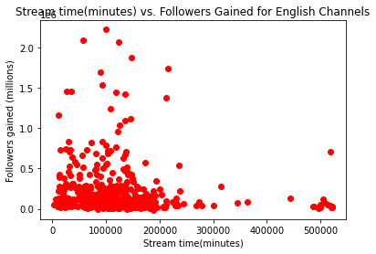

```python
# Stream time(minutes) vs. Followers Gained for English Channels

# Preliminary plot setup
plt.xlabel('Stream time(minutes)')
plt.ylabel('Followers gained (millions)')
plt.title('Stream time(minutes) vs. Followers Gained for English Channels')

# Create the plot
plt.scatter(english_table['Stream time(minutes)'], english_table['Followers gained'], color = 'r')

# Optionally add labels for each dot
#[plt.text(x = english_table['Stream time(minutes)'][j], y = english_table['Followers gained'][j], s = english_table['Channel'][j]) for j in range(485)]

# Show the plot
plt.show()
```

### Intermediate Analysis

What we see here is interesting: a majority of channels that brought in the most followers in the one year period streamed for **much** less time than those who did not gain many more followers. To confirm this, we can visualize the linear regression of the plot and analyze the plot. If there is a downwards trend, we have successfully proved our simple hypothesis, and rejected the null hypothesis. Thanks to the seaborn library we imported earlier, regression lines can be done with around three lines of code, and customized greatly. However, we can also make use of the powerful sklearn library to find the coefficient of our linear regression without even plotting the data. We are going to do that first, and then plot the line. More information on the seaborn library and its plotting capabilities can be found at: https://seaborn.pydata.org/tutorial/regression.html.

```python
# Import the necessary libraries
import numpy as np
import sklearn.linear_model as lin_mod

# Create NumPy arrays and reshape them for input in the fit function
str_time = np.array(english_table['Stream time(minutes)'])
str_time = str_time.reshape(-1,1)
foll_gain = np.array(english_table['Followers gained'])
foll_gain = foll_gain.reshape(-1,1)

# Create the Linear Regression model object
reg_mod = lin_mod.LinearRegression()

# Fit our data to the model
reg_fit = reg_mod.fit(x, y)

# Extract the coefficient
reg_fit.coef_
```

[output not shown]

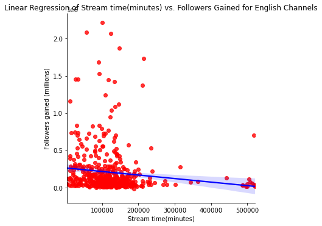

```python
# LinReg of Stream time(minutes) vs. Followers Gained for English Channels
sns.lmplot(x = "Stream time(minutes)", y = "Followers gained", data = english_table, fit_reg = True, scatter_kws={'color': 'r'}, line_kws={'color': 'b'})
plt.title('Linear Regression of Stream time(minutes) vs. Followers Gained for English Channels')
plt.ylabel('Followers gained (millions)')
plt.show()
```

### Further Analysis

Another interesting relationship, and a common one in social media, is the followers to activity ratio. This is also known as a way of measuring 'active followers', that engage in the content being created and shared. Followers mean almost nothing to streamers if they are not actively tuning in to watch streams and interacting in chat. To calculate active followers, we will perform a calculation between the *Average Viewers* and *Followers* columns to create a new column.

```python
# New empty list to hold the calculated values
new_col = []

# Iterate through the table and calculate the active followers
for index, row in english_table.iterrows():
    new_col.append(row['Average viewers'] / row['Followers'] * 100)

# Add the new column to our DataFrame
english_table['Active Followers(%)'] = new_col

# Sort by the active followers and fix the indices
english_table = english_table.sort_values(by = ['Active Followers(%)'], ascending = False)
english_table = english_table.reset_index(drop = True)

# Display the table's first 20 entries
english_table.head(20)
```

|  | Channel | Watch time(Minutes) | Stream time(minutes) | Peak viewers | Average viewers | Followers | Followers gained | Views gained | Active Followers(%) |
| --- | --- | --- | --- | --- | --- | --- | --- | --- | --- |
| 0 | KEEMSTAR | 123365895 | 3465 | 74195 | 35333 | 146035 | 46367 | 7139253 | 24.194885 |
| 1 | dota2ti | 1017577605 | 6315 | 483530 | 147643 | 663297 | 121422 | 16228039 | 22.258958 |
| 2 | Flashpoint | 311325840 | 19320 | 77708 | 11713 | 93616 | 93120 | 27828448 | 12.511750 |
| 3 | OGADotaPIT | 216072855 | 18705 | 60846 | 10161 | 157820 | 48664 | 8333671 | 6.438347 |
| 4 | AlcastHQ | 132082785 | 28905 | 12999 | 4680 | 81928 | 24582 | 41833833 | 5.712333 |
| 5 | FENGRUSH | 521568750 | 100605 | 16128 | 4985 | 95643 | 23288 | 44675247 | 5.212091 |
| 6 | BLASTPremier | 753808200 | 25260 | 113167 | 24689 | 501371 | 315910 | 21104122 | 4.924298 |
| 7 | PardonMyTake | 156004485 | 25140 | 141406 | 6728 | 143916 | 143806 | 3300371 | 4.674949 |
| 8 | twlevewinsHS | 174228915 | 102900 | 5425 | 1711 | 38410 | 31257 | 1353428 | 4.454569 |
| 9 | DesertHeartsRecords | 276313155 | 64620 | 24264 | 3620 | 85097 | 84304 | 58418224 | 4.253969 |
| 10 | BeatportOfficial | 180850230 | 27765 | 48457 | 5300 | 126546 | 124653 | 36484452 | 4.188200 |
| 11 | LCS | 1461310140 | 31125 | 214124 | 46459 | 1162746 | 526244 | 28313058 | 3.995628 |
| 12 | NiteNightKid | 178419030 | 149040 | 29228 | 1127 | 28818 | 11998 | 1450208 | 3.910750 |
| 13 | LCK | 1351758525 | 37140 | 171861 | 36030 | 934688 | 307853 | 28970100 | 3.854762 |
| 14 | Fextralife | 3301867485 | 147885 | 68795 | 18985 | 508816 | 425468 | 670137548 | 3.731211 |
| 15 | StarLadder_cs_en | 1088832810 | 32880 | 329195 | 29956 | 820675 | 260993 | 29821162 | 3.650166 |
| 16 | WOKE | 235303170 | 51600 | 50598 | 3827 | 107484 | 105725 | 3460437 | 3.560530 |
| 17 | WePlayEsport_EN | 704823000 | 107745 | 87751 | 6127 | 175061 | 137229 | 17857171 | 3.499923 |
| 18 | LPL | 850636305 | 48765 | 146577 | 17573 | 502467 | 280538 | 31029241 | 3.497344 |
| 19 | MadDecentLive | 129993915 | 42510 | 36968 | 3069 | 95371 | 95352 | 44291541 | 3.217959 |

### Active Followers

When I said earlier that followers mean *almost* nothing if they aren't watching, that is because sponsors and advertisers still use follow count as a crucial metric for handing out deals. The follower count represents a total *potential* audience that have engaged with a channel in the past and could still tune in occasionally. Still, I believe that active followers are a better representation of engagement, and watch time is the ultimate factor. As such, we will be plotting the relationship between the two here.

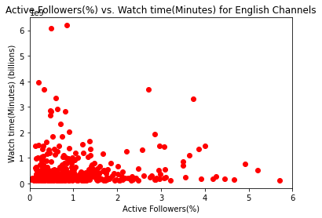

```python
# Active Followers(%) vs. Watch time(Minutes) for English Channels

# Preliminary plot setup
plt.xlabel('Active Followers(%)')
plt.ylabel('Watch time(Minutes) (billions)')
plt.title('Active Followers(%) vs. Watch time(Minutes) for English Channels')

# Create the plot
plt.scatter(english_table['Active Followers(%)'], english_table['Watch time(Minutes)'], color = 'r')

# Ignore outliers for a zoomed in view
plt.xlim([0, 6])

# Optionally add labels for each dot
#[plt.text(x = english_table['Active Followers(%)'][j], y = english_table['Watch time(Minutes)'][j], s = english_table['Channel'][j]) for j in range(485)]

# Show the plot
plt.show()
```

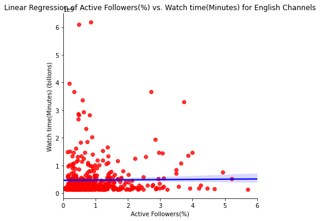

```python
# LinReg of Active Followers(%) vs. Watch time(Minutes) for English Channels
sns.lmplot(x = "Active Followers(%)", y = "Watch time(Minutes)", data = english_table, fit_reg = True, scatter_kws={'color': 'r'}, line_kws={'color': 'b'})

# Set title and fix label
plt.title('Linear Regression of Active Followers(%) vs. Watch time(Minutes) for English Channels')
plt.ylabel('Watch time(Minutes) (billions)')

# Ignore outliers for a zoomed in view
plt.xlim([0, 6])

# Show the plot
plt.show()
```

### Even More Plots

With our hypothesis out of the way, let's plot some more variables with each other and organically draw conclusions from the plots and their respective regressions. We don't always have to have a theory going into the process, oftentimes trends will become apparent through simply viewing the data from another perspective.

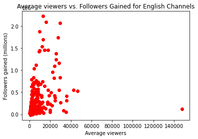

```python
# Average viewers vs. Followers Gained for English Channels

# Preliminary plot setup
plt.xlabel('Average viewers')
plt.ylabel('Followers gained (millions)')
plt.title('Average viewers vs. Followers Gained for English Channels')

# Create the plot
plt.scatter(english_table['Average viewers'], english_table['Followers gained'], color = 'r')

# Optionally add labels for each dot
#[plt.text(x = english_table['Average viewers'][j], y = english_table['Followers gained'][j], s = english_table['Channel'][j]) for j in range(485)]

# Show the plot
plt.show()
```

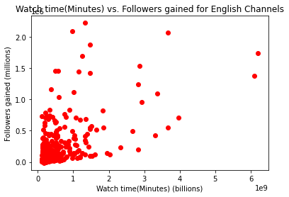

```python
# Watch time(Minutes) vs. Followers Gained for English Channels

# Preliminary plot setup
plt.xlabel('Watch time(Minutes) (billions)')
plt.ylabel('Followers gained (millions)')
plt.title('Watch time(Minutes) vs. Followers gained for English Channels')

# Create the plot
plt.scatter(english_table['Watch time(Minutes)'], english_table['Followers gained'], color = 'r')

# Optionally add labels for each dot
#[plt.text(x = english_table['Watch time(Minutes)'][j], y = english_table['Followers gained'][j], s = english_table['Channel'][j]) for j in range(485)]

# Show the plot
plt.show()
```

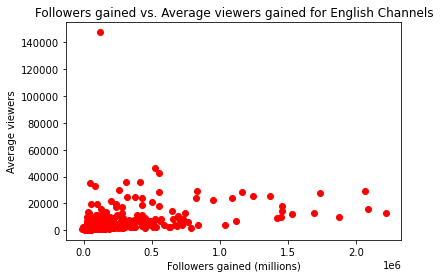

```python
# Watch time(Minutes) vs. Followers Gained for English Channels

# Preliminary plot setup
plt.xlabel('Followers gained (millions)')
plt.ylabel('Average viewers')
plt.title('Followers gained vs. Average viewers gained for English Channels')

# Create the plot
plt.scatter(english_table['Followers gained'], english_table['Average viewers'], color = 'r')

# Optionally add labels for each dot
#[plt.text(x = english_table['Followers gained'][j], y = english_table['Average viewers'][j], s = english_table['Channel'][j]) for j in range(485)]

# Show the plot
plt.show()
```

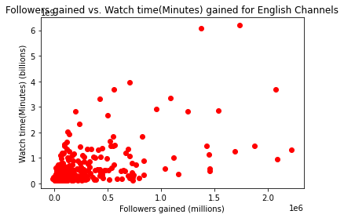

```python
# Watch time(Minutes) vs. Followers Gained for English Channels

# Preliminary plot setup
plt.xlabel('Followers gained (millions)')
plt.ylabel('Watch time(Minutes) (billions)')
plt.title('Followers gained vs. Watch time(Minutes) gained for English Channels')

# Create the plot
plt.scatter(english_table['Followers gained'], english_table['Watch time(Minutes)'], color = 'r')

# Optionally add labels for each dot
#[plt.text(x = english_table['Followers gained'][j], y = english_table['Watch time(Minutes)'][j], s = english_table['Channel'][j]) for j in range(485)]

# Show the plot
plt.show()
```

### Methods

Analysis of the plotted data can come in many shapes and forms. We could perform a linear regression on the plots, standardize the datasets, compute average coefficients, or even visually comment on the trends. Before we even begin any of these methods, we can visually see that all of these plots have a positive correlation, even if many of them vary in their slope. To examine and solidify this observation, this tutorial will be continuing with creating a linear regression for each of the plots. Without this step, we cannot effectively communicate with an audience what we might possibly be seeing. Visual depictions and further mathematical analysis can only aid in getting the point across, especially to an audience unfamiliar with the source material.

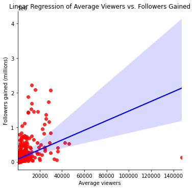

```python
# LinReg of Average viewers vs. Followers Gained for English Channels
sns.lmplot(x = "Average viewers", y = "Followers gained", data = english_table, fit_reg = True, robust = True, scatter_kws={'color': 'r'}, line_kws={'color': 'b'})
plt.ylabel('Followers gained (millions)')
plt.title('Linear Regression of Average Viewers vs. Followers Gained')
plt.show()
```

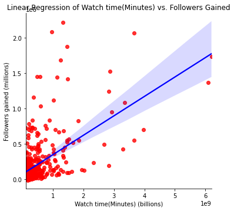

```python
# LinReg of Watch time(Minutes) vs. Followers Gained for English Channels
sns.lmplot(x = "Watch time(Minutes)", y = "Followers gained", data = english_table, fit_reg = True, scatter_kws={'color': 'r'}, line_kws={'color': 'b'})
plt.title('Linear Regression of Watch time(Minutes) vs. Followers Gained')
plt.xlabel('Watch time(Minutes) (billions)')
plt.ylabel('Followers gained (millions)')
plt.show()
```

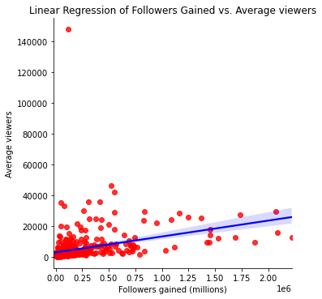

```python
# LinReg of Watch time(Minutes) vs. Followers Gained for English Channels
sns.lmplot(x = "Followers gained", y = "Average viewers", data = english_table, fit_reg = True, scatter_kws={'color': 'r'}, line_kws={'color': 'b'})
plt.title('Linear Regression of Followers Gained vs. Average viewers')
plt.xlabel('Followers gained (millions)')
plt.show()
```

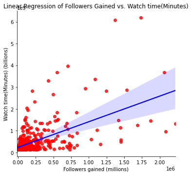

```python
# LinReg of Watch time(Minutes) vs. Followers Gained for English Channels
sns.lmplot(x = "Followers gained", y = "Watch time(Minutes)", data = english_table, fit_reg = True, scatter_kws={'color': 'r'}, line_kws={'color': 'b'})
plt.title('Linear Regression of Followers Gained vs. Watch time(Minutes)')
plt.xlabel('Followers gained (millions)')
plt.ylabel('Watch time(Minutes) (billions)')
plt.show()
```

### The Four Plots & Final Analysis

At a basic level, we can make observations from the regressions for each of the plots in order. As average viewers go up, so do new followers. As watch time goes up, once again new followers go up as well. In the reverse, as followers are gained, average viewership also increases. Lastly, as followers are gained, watch time follows suit. Many of these seem to be very obvious conclusions: more people watching results in interested viewers following the channels, and if more individuals follow the channels they are likely to keep watching and increase viewership. Although they are very apparent, I chose these plots to show the cyclical relationship in the Twitch ecosystem, and what factors break into this cycle every so often that we cannot see here.

## Conclusion

The Data Science Pipeline is an intricate and effective procedure for working with datasets and presenting your personal analysis on the topic. We have covered up until this point various methods to pull data, tidy it up, represent it, analyze it, and communicate it to an audience. Hopefully you were able to learn about data science through a popular topic that I enjoy, and are encouraged to perform your own analysis!

## Additional Resources

- https://www.twitch.tv/
- https://www.kaggle.com/
- https://matplotlib.org/
- https://seaborn.pydata.org/index.html
- https://pandas.pydata.org/docs/
- https://scikit-learn.org/stable/